# About the project

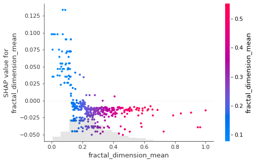

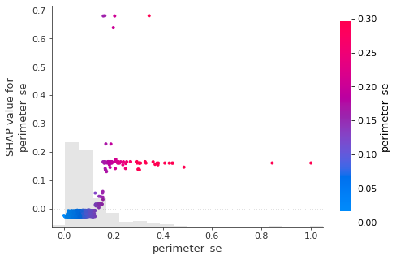

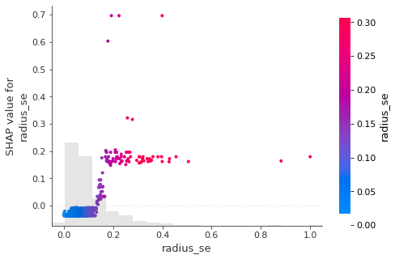

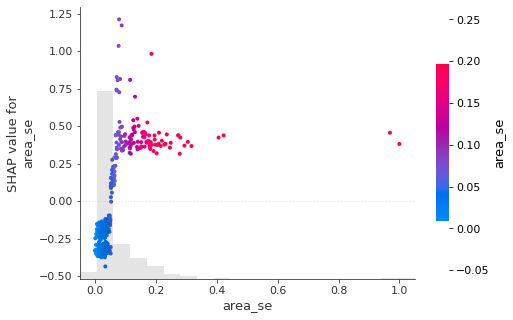

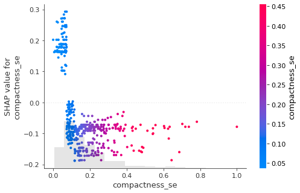

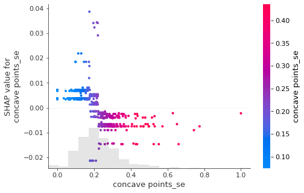

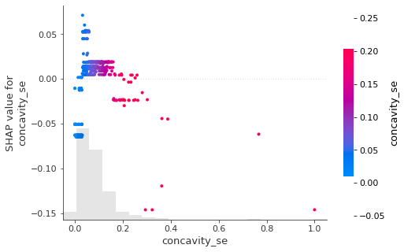

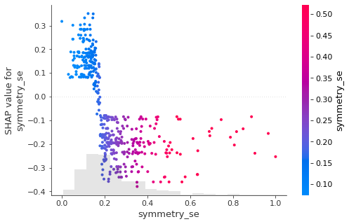

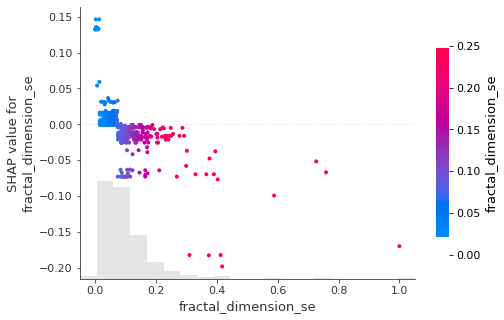

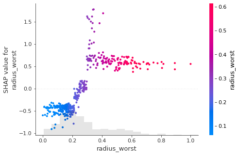

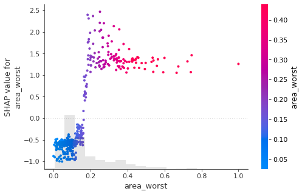

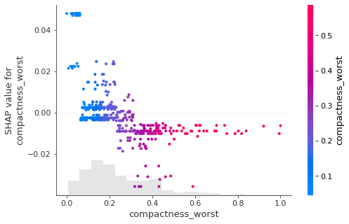

[3 more figures not shown]

```python
# The scatter plot below shows the effect of a single feature across the whole dataset, and the model's predictions.
featurs = ["fractal_dimension_mean", "perimeter_se", "radius_se", "area_se", "compactness_se", "concave points_se", "concavity_se", "symmetry_se", "fractal_dimension_se", "radius_worst", "area_worst", "compactness_worst", "concave points_worst", "concavity_worst", "symmetry_worst"]

for feature in featurs:
    shap.plots.scatter(shap_values[:, feature], color=shap_values[:, feature])
    plt.show()
```

```
0.956140350877193
```

```
<sklearn.metrics._plot.confusion_matrix.ConfusionMatrixDisplay at 0x7fc6114a5e80>
```

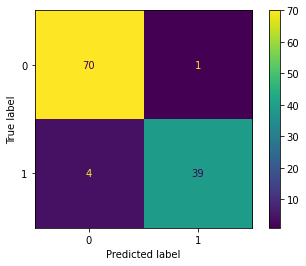

```python
"""

Implementing Support Vector Machine.
Support Vector Machines are supervised learning models for classification and regression problems.
They can solve linear and non-linear problems and work well for many practical problems.
The idea of this model is to find a hyperplane that separates the data into two classes,
and then to classify new data points based on the distance to the hyperplane.
The goal of the line is to maximizing the margin between the points on either side of the so called decision line (the hyperplane)
so that the points on the one side of the line are more likely to be classified as belonging to the positive class, and the points on the other side are more likely to be classified as belonging to the negative class.

"""

from sklearn.svm import SVC # Support Vector Classifier
sv = SVC(kernel='rbf', C=1, gamma=0.1)
# kernel is the type of kernel function to use in the algorithm (linear, poly, rbf, sigmoid, precomputed).
# C is the penalty parameter of the error term.
# gamma is the parameter of the kernel function.
sv.fit(X_train, y_train)
pred_svc = sv.predict(X_test)


print(accuracy_score(y_test, pred_svc))

cm = confusion_matrix(y_test, pred_svc, labels=sv.classes_)
disp = ConfusionMatrixDisplay(confusion_matrix=cm,display_labels=sv.classes_)
disp.plot()
```

```python
# Implemnting grid search for the support vector machine algorithm

grid_cv = GridSearchCV(estimator=sv, param_grid={'C': [0.1, 1, 10, 100, 1000], 'gamma': [0.1, 0.01, 0.001, 0.0001, 0.00001], 'kernel': ['linear', 'rbf']},  scoring='accuracy', cv=10)
#scoring is the metric used to evaluate the model.
grid_cv.fit(X_train, y_train)

print(grid_cv.best_params_) #the best parameters for the support vector machine algorithm
print(grid_cv.best_score_) #the best score for the support vector machine algorithm
```

```
{'C': 1, 'gamma': 0.1, 'kernel': 'linear'}
0.9757971014492753
```

```python
"""

Implemting naive bayes classifier.
naive bayes classifier is a simple classifier that assumes that the features are independent of each other.
A Naive Bayes classifier is a probabilistic machine learning model base on Bayes theorem.

"""

from sklearn.naive_bayes import GaussianNB
naive = GaussianNB()
naive.fit(X_train, y_train)
pred_naive = naive.predict(X_test)
print(accuracy_score(y_test, pred_naive))
```

```
0.9649122807017544
```

# Implementing Neural Network Algorithm

### Neural Networks are a type of artificial neural network, which is a type of artificial neural network that is based on the idea of a network of neurons.

The neurons are connected by a weight matrix, which is a matrix of weights that connect the neurons.

each neuron is connected to all the other neurons in the network, and the weights are updated based on the error of the output of the neuron.

each neuron has activation function, which is a function that maps the input to the output.

we are going to use Neural Network for classification problems, however today Neural Network is used for both classification and regression problems.

we will be using the Keras library to implement the Neural Network.

```python
# Neural Network algorithm

model = Sequential()

model.add(Dense(units=100, activation='relu', input_shape=(X_train.shape[1],)))
model.add(Dense(units=100, activation='relu'))
model.add(Dense(units=1, activation='sigmoid'))

# relu is the rectified linear unit function, which is a function that returns the max of 0 and the input.
# sigmod refers to the sigmoid function, which is a function that maps the input to the output.

optemizer = keras.optimizers.Adam(lr=0.001)
# lr is the learning rate, which is the step size of the gradient descent algorithm.
# adam optimizer is a stochastic gradient descent algorithm.

model.compile(optimizer=optemizer, loss='binary_crossentropy', metrics=['accuracy'])
# loss is the loss function, which is the function that measures the difference between the output and the expected output.
# binary_crossentropy is the loss function for binary classification.
# matrics is the list of metrics to be used to evaluate the model, which is the function that measures the performance of the model.

model.fit(X_train, y_train, epochs=50, batch_size=10)
```

[output not shown]

```
<tensorflow.python.keras.callbacks.History at 0x7fc5f7378a30>
```

```python
loss, accuracy = model.evaluate(X_test, y_test)
print(f' Model loss on the test set: {loss}')
print(f' Model accuracy on the test set: {100*accuracy}')
```

```
 Model loss on the test set: 0.06160027161240578
 Model accuracy on the test set: 96.49122953414917
```

```
<sklearn.metrics._plot.confusion_matrix.ConfusionMatrixDisplay at 0x7fc5f8872b50>
```

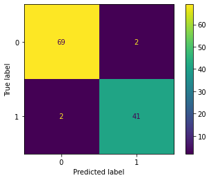

```python
# Predicting the test set

pred_nn = model.predict(X_test)
# Plot the confusion matrix
cm = confusion_matrix(y_test, pred_nn.round())
disp = ConfusionMatrixDisplay(confusion_matrix=cm)
disp.plot()
```

```python
""" summary of the model """

summary = model.summary() #summary of the model
print(summary)
```

```
Model: "sequential"
_________________________________________________________________
Layer (type)                 Output Shape              Param #
=================================================================
dense (Dense)                (None, 100)               3200
_________________________________________________________________
dense_1 (Dense)              (None, 100)               10100
_________________________________________________________________
dense_2 (Dense)              (None, 1)                 101
=================================================================
Total params: 13,401
Trainable params: 13,401
Non-trainable params: 0
_________________________________________________________________
None
```

# *summary*

### In this work, we have used the following libraries:

1. pandas, which is a library for data manipulation and analysis.
2. numpy, which is a library for scientific computing and high-level mathematical functions.
3. matplotlib, which is a library for plotting graphs.
4. seaborn, which is a library for statistical data visualization.
5. sklearn, uses the machine learning algorithms to train and test the model.
6. keras, which is a library for building deep learning models.
7. tensorflow, deep learning library uses for building neural networks.

First, we uses the pandas library to read the data and store it in a dataframe, then we uses the info and describe functions to get some information about the data.

we learn and clean the data using descriptive statistics and visualizations (in this case, we use the seaborn and matplotlib library to plot the data).

We also uses preprocessing techniques such as scaling and normalization, we didnt need to use onehotencodeing because we didnt have any categorical variables (other then the target variable).

later on, we use the machine learning algorithms to train and test the model.

The machine learning algorithms are used to train the model to predict the output of the data, in this case, the output is the class of the breast cancer classification.

All the models we use were classification models, since our traget variable is binary, and this is a classification problem.

By using the confusion matrix, we can see how well the model is performing.

## *Conclusion and future work*

I believe that the machine learning algorithms are very useful in the field of healthcare. I find this to be a very interesting field, and I am looking forward to learn more about it.

As for further research, I am looking forward to learn more about the machine learning algorithms, deep learning algorithms, and computer vision algorithms within the field of healthcare.

I belive that with more data, and more complex algorithms, the machine learning algorithms will be more and more accurate and therefore we cound use it at the healthcare industry, what could be a great opportunity to make this industry more efficient.

Below you can see the results and scores of each algorithm.

```python
print("The scores of the models are:")

print('Accuracy of k-nearest neighbors (k-NN): %.3f' % accuracy_score(y_test, pred_knn))
print('Accuracy of support vector machine (SVM): %.3f' % accuracy_score(y_test, pred_svc))
print('Accuracy of naive bayes classifier: %.3f' % accuracy_score(y_test, pred_naive))
print('Accuracy of logistic regression: %.3f' % accuracy_score(y_test, pred_lr))
print('Accuracy of Random Forest: %.3f' % accuracy_score(y_test, pred_rf))
print('Accuracy of XGB: %.3f' % accuracy_score(y_test, pred_xbg))
print('Accuracy of neural network: %.3f' % accuracy_score(y_test, pred_nn.round()))
```

```
The scores of the models are:
Accuracy of k-nearest neighbors (k-NN): 0.974
Accuracy of support vector machine (SVM): 0.956
Accuracy of naive bayes classifier: 0.965
Accuracy of logistic regression: 0.982
Accuracy of Random Forest: 0.956
Accuracy of XGB: 0.947
Accuracy of neural network: 0.965
```